# Introduction to pypomp

Published

September 11, 2026

← Back to Tutorials README

This document showcases basic functions in `pypomp`. We build a simple partially observed Markov process (POMP) model from scratch, simulate data from it, estimate its likelihood with the particle filter, and estimate its parameters with iterated filtering 2 (IF2). Because the model is linear and Gaussian, its exact likelihood is available from the Kalman filter, so we can check the Monte Carlo answers from `pypomp` against the truth.

## Setup and Imports

First, we import the necessary packages.

```python
import jax
import jax.numpy as jnp
import numpy as np
import pandas as pd
import plotnine as p9
from scipy import optimize, stats

import pypomp as pp
from pypomp.types import *

print(f"pypomp version: {pp.__version__}")
print(f"JAX version: {jax.__version__}")
```

```
pypomp version: 1.0.2
JAX version: 0.11.1
```

## The Model

We use a first-order autoregressive, or AR(1), process observed with noise. The latent state $X_n$ evolves according to
$$X_n = \phi X_{n-1} + \sigma_X \varepsilon_n, \qquad \varepsilon_n \sim \mathcal{N}(0, 1),$$
and at each time $n = 1, \dots, N$ we observe
$$Y_n = X_n + \sigma_Y \eta_n, \qquad \eta_n \sim \mathcal{N}(0, 1),$$
where all $\varepsilon_n$ and $\eta_n$ are independent. We require $|\phi| < 1$ so that the process is stationary, and we draw the initial state $X_0$ from the stationary distribution $\mathcal{N}\big(0, \sigma_X^2 / (1 - \phi^2)\big)$. The model has three parameters: the autoregressive coefficient $\phi$, the process noise standard deviation $\sigma_X$, and the measurement noise standard deviation $\sigma_Y$.

## Defining Model Mechanics

A POMP model in `pypomp` is specified by up to four functions, which we call the model mechanics:

- `rinit` simulates the initial state $X_0$.
- `rproc` simulates one step of the latent process, from $X_{n-1}$ to $X_n$.
- `dmeas` evaluates the log-density of an observation $Y_n$ given the state $X_n$.
- `rmeas` simulates an observation $Y_n$ given the state $X_n$.

`rinit`, `rproc`, and `rmeas` return dictionaries keyed by the names of the state or observation variables, and `dmeas` returns a scalar log-density. Parameters, states, and observations are passed in as dictionaries as well, so the model code can refer to each quantity by name.

`pypomp` calls these functions internally, so it needs to know which argument is which. It matches arguments using the type hints in `pypomp.types` (such as `ParamDict` and `RNGKey`) or, for arguments without these hints, the default argument names (`theta_`, `key`, `X_`, `Y_`, `covars`, `t`, `t0`, and `dt`). We use both below. Every expected argument must be present, even if the function does not use it. Our model has no covariates and its dynamics do not depend on time, so `covars`, `t`, `t0`, and `dt` go unused here.

```python
def rinit(theta_: ParamDict, key: RNGKey, covars: CovarDict, t0: InitialTimeFloat):
    """Draw X_0 from the stationary distribution of the AR(1) process."""
    sd = theta_["sigma_x"] / jnp.sqrt(1 - theta_["phi"] ** 2)
    return {"X": sd * jax.random.normal(key)}


def rproc(
    X_: StateDict,
    theta_: ParamDict,
    key: RNGKey,
    covars: CovarDict,
    t: TimeFloat,
    dt: StepSizeFloat,
):
    """Advance the latent AR(1) process by one step."""
    X = theta_["phi"] * X_["X"] + theta_["sigma_x"] * jax.random.normal(key)
    return {"X": X}


def dmeas(
    Y_: ObservationDict,
    X_: StateDict,
    theta_: ParamDict,
    covars: CovarDict,
    t: TimeFloat,
):
    """Log-density of the observation given the latent state."""
    return jax.scipy.stats.norm.logpdf(Y_["Y"], loc=X_["X"], scale=theta_["sigma_y"])


def rmeas(
    X_: StateDict,
    theta_: ParamDict,
    key: RNGKey,
    covars: CovarDict,
    t: TimeFloat,
):
    """Simulate an observation given the latent state."""
    return {"Y": X_["X"] + theta_["sigma_y"] * jax.random.normal(key)}
```

Each function handles a single particle and a single parameter set. `pypomp` uses JAX to vectorize them over particles and parameter sets and to compile them, so there is no need to write loops.

## Parameter Transformations

The algorithms `pypomp` uses to search the parameter space assume that the parameters can take any real value. Our parameters are constrained: $\phi$ lies in $(-1, 1)$ and the standard deviations are positive. We therefore write functions that map the parameters to an unconstrained “estimation scale” and back, and store them in a `ParTrans` object. Here, we use the inverse hyperbolic tangent for $\phi$ and the logarithm for the standard deviations.

```python
def to_est(theta: ParamDict) -> ParamDict:
    return {
        "phi": jnp.arctanh(theta["phi"]),
        "sigma_x": jnp.log(theta["sigma_x"]),
        "sigma_y": jnp.log(theta["sigma_y"]),
    }


def from_est(theta: ParamDict) -> ParamDict:
    return {
        "phi": jnp.tanh(theta["phi"]),
        "sigma_x": jnp.exp(theta["sigma_x"]),
        "sigma_y": jnp.exp(theta["sigma_y"]),
    }


ptrans = pp.ParTrans(to_est=to_est, from_est=from_est)
```

## Model Construction & Simulation

We now construct the POMP model object with `pp.Pomp`. Parameters are supplied as a `PompParameters` object, which can hold one or more parameter sets. Observation times are given by the row index of the data frame of observations, and `t0` sets the time of the initial state. `nstep=1` tells `pypomp` to call `rproc` once per observation interval.

We do not have real data in this example, so we generate our own. We first construct the model with a placeholder data frame that has the desired observation times and column name.

```python
theta_true = {"phi": 0.9, "sigma_x": 1.0, "sigma_y": 1.0}
N = 200
ys_placeholder = pd.DataFrame({"Y": np.zeros(N)}, index=np.arange(1.0, N + 1))

ar1_template = pp.Pomp(
    ys=ys_placeholder,
    theta=pp.PompParameters(theta_true),
    statenames=["X"],
    t0=0.0,
    rinit=rinit,
    rproc=rproc,
    dmeas=dmeas,
    rmeas=rmeas,
    nstep=1,
    par_trans=ptrans,
)
```

JAX handles random numbers differently from NumPy. Instead of a global random state, every random function takes an explicit pseudorandom number generator (PRNG) key, and the same key always gives the same result. We create a key and split it whenever we need a new one.

`Pomp.simulate()` returns data frames of simulated states and observations.

```python
key = jax.random.key(1)
key, subkey = jax.random.split(key)
X_sim, Y_sim = ar1_template.simulate(key=subkey)
Y_sim.head()
```

|  | theta_idx | sim | time | Y |
| --- | --- | --- | --- | --- |
| 0 | 0 | 0 | 1.0 | 1.507848 |
| 1 | 0 | 0 | 2.0 | -0.490220 |
| 2 | 0 | 0 | 3.0 | 1.440536 |
| 3 | 0 | 0 | 4.0 | 1.415157 |
| 4 | 0 | 0 | 5.0 | -1.506160 |

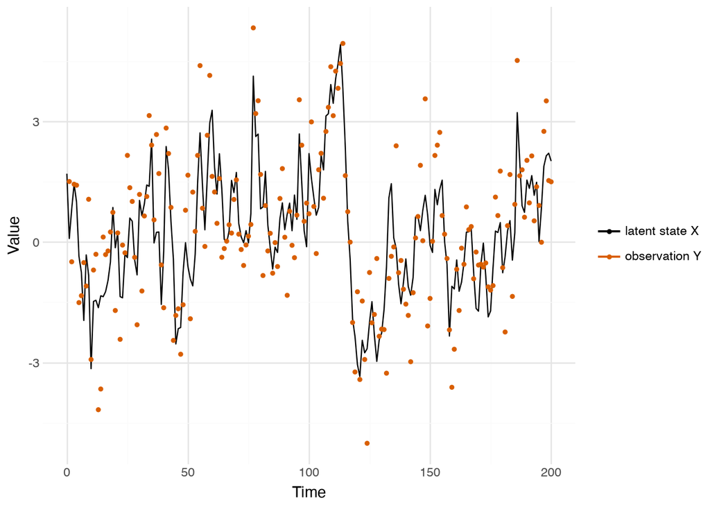

```python
(
    p9.ggplot()
    + p9.geom_line(p9.aes(x="time", y="X", color='"latent state X"'), data=X_sim)
    + p9.geom_point(p9.aes(x="time", y="Y", color='"observation Y"'), data=Y_sim, size=1)
    + p9.scale_color_manual(values=["black", "#d95f02"])
    + p9.theme_minimal()
    + p9.labs(x="Time", y="Value", color="")
)
```

Calling `simulate()` again with the same key and `as_pomp=True` reproduces the same draw, but returns a new `Pomp` object with the simulated observations as its data. This is the model we fit for the rest of the tutorial.

```python
ar1 = ar1_template.simulate(key=subkey, as_pomp=True)
np.allclose(ar1.ys["Y"], Y_sim["Y"])
```

```
True
```

## Likelihood Evaluation with the Particle Filter

The likelihood of a POMP model is usually intractable, so `pypomp` estimates it with the particle filter, which is implemented as the `Pomp` method `pfilter()`. The argument `J` sets the number of particles and `reps` sets the number of independent replicate filters.

Unlike the R family of POMP packages, some `Pomp` methods, including `pfilter()`, `mif()`, and `train()`, store their results in the object instead of returning new objects. Results are appended to the list `ar1.results_history`, with one element per method call. Each element contains the outputs, such as log-likelihood estimates, and the inputs used for the call, so it is easy to keep track of how each result was produced. The method `results()` returns the results of one call as a tidy data frame (by default, the most recent call). The log-likelihood reported by `pfilter()` averages the replicates on the likelihood scale, and `se` is its Monte Carlo standard error.

Each method that takes a key also stores an unused child key under `ar1.fresh_key`, which later calls use by default when no key is given. Below, we give the first call a key and let the others use `fresh_key`.

```python
key, subkey = jax.random.split(key)
ar1.pfilter(J=100, reps=10, key=subkey)
ar1.results()
```

|  | theta_idx | logLik | se | phi | sigma_x | sigma_y |
| --- | --- | --- | --- | --- | --- | --- |
| 0 | 0 | -374.331915 | 0.483449 | 0.9 | 1.0 | 1.0 |

To check this estimate, we compute the exact log-likelihood with the Kalman filter, which is only a few lines of code for this model.

```python
def kalman_loglik(theta: dict[str, float], y: np.ndarray) -> float:
    """Exact log-likelihood of the AR(1) plus noise model."""
    phi, sigma_x, sigma_y = theta["phi"], theta["sigma_x"], theta["sigma_y"]
    m, P = 0.0, sigma_x**2 / (1 - phi**2)  # stationary distribution of X_0
    loglik = 0.0
    for y_n in y:
        m, P = phi * m, phi**2 * P + sigma_x**2  # predict X_n
        S = P + sigma_y**2  # predictive variance of Y_n
        loglik += stats.norm.logpdf(y_n, m, np.sqrt(S))
        K = P / S  # Kalman gain
        m, P = m + K * (y_n - m), (1 - K) * P  # update given Y_n
    return loglik


y = ar1.ys["Y"].to_numpy()
exact_loglik = kalman_loglik(theta_true, y)
exact_loglik
```

```
np.float64(-373.2145225685712)
```

The particle filter estimate becomes more precise as we increase the number of particles. The particle filter’s estimate of the likelihood is unbiased, but taking its logarithm introduces a small downward bias, which also shrinks as the number of particles grows.

```python
for J in [100, 1_000, 10_000]:
    ar1.pfilter(J=J, reps=10)

pd.DataFrame(
    {
        "J": [100, 1_000, 10_000],
        "logLik": [ar1.results(i)["logLik"].item() for i in [-3, -2, -1]],
        "se": [ar1.results(i)["se"].item() for i in [-3, -2, -1]],
        "exact logLik": exact_loglik,
    }
)
```

|  | J | logLik | se | exact logLik |
| --- | --- | --- | --- | --- |
| 0 | 100 | -373.171349 | 1.257857 | -373.214523 |
| 1 | 1000 | -373.425199 | 0.099352 | -373.214523 |
| 2 | 10000 | -373.228027 | 0.055475 | -373.214523 |

## Parameter Estimation with Iterated Filtering

We now pretend that we do not know the parameters and estimate them. We implement IF2 as the `Pomp` method `mif()`. IF2 adds random walk perturbations to the parameters and runs a particle filter on the perturbed model, gradually shrinking, or “cooling”, the perturbations over repeated iterations until the parameters settle near the maximum likelihood estimate (MLE).

Starting a search from several different parameter values is good practice, because it explores more of the parameter space and shows whether the searches agree. `Pomp.sample_params()` draws parameter sets from uniform distributions with bounds given as a dictionary of length-2 tuples and returns them in a `PompParameters` object. Methods such as `mif()` and `pfilter()` run on every parameter set in a `PompParameters` object at once, so there is no need to make a new `Pomp` object for each set. In fact, methods like `mif()` and `pfilter()` are optimized to run substantially faster when operating on multiple parameter sets at once instead of running them sequentially.

```python
key, subkey = jax.random.split(key)
starts = pp.Pomp.sample_params(
    {"phi": (0.0, 0.95), "sigma_x": (0.2, 3.0), "sigma_y": (0.2, 3.0)},
    n=8,
    key=subkey,
)
```

The random walk standard deviations are set with an `RWSigma` object and apply on the estimation scale. Parameters listed in its optional `init_names` argument would be perturbed only at the initial time $t_0$, which is useful for parameters that only affect the initial state. Our model has no such parameters, so we perturb all of them at every time step. `geometric_cooling(a=0.5)` gradually shrinks the perturbations, totaling to a factor of 0.5 every 50 iterations.

```python
rw_sd = pp.RWSigma(
    sigmas={"phi": 0.02, "sigma_x": 0.02, "sigma_y": 0.02}
).geometric_cooling(a=0.5)
```

We pass the starting values through the `theta` argument, run `M=100` iterations of IF2 with `J=1000` particles, and then evaluate the resulting estimates with the particle filter. `mif()` also replaces `ar1.theta` with the parameter estimates from its last iteration, so the following `pfilter()` call evaluates these estimates by default.

```python
ar1.mif(J=1_000, M=100, rw_sd=rw_sd, theta=starts)
ar1.pfilter(J=2_000, reps=10)
ar1.results()
```

|  | theta_idx | logLik | se | phi | sigma_x | sigma_y |
| --- | --- | --- | --- | --- | --- | --- |
| 0 | 0 | -370.555998 | 0.102340 | 0.813221 | 1.038959 | 0.968086 |
| 1 | 1 | -370.626290 | 0.102300 | 0.824400 | 0.880811 | 1.065401 |
| 2 | 2 | -371.216794 | 0.123509 | 0.742447 | 1.017276 | 0.858695 |
| 3 | 3 | -370.140258 | 0.136056 | 0.768908 | 1.037989 | 0.925975 |
| 4 | 4 | -370.552617 | 0.120507 | 0.743149 | 0.995955 | 1.039094 |
| 5 | 5 | -370.553294 | 0.108907 | 0.789364 | 0.932984 | 1.057886 |
| 6 | 6 | -370.279510 | 0.125699 | 0.748558 | 1.105699 | 0.865771 |
| 7 | 7 | -370.526143 | 0.184539 | 0.778799 | 0.998189 | 0.931117 |

**Note**

JAX’s GPU acceleration enables `pypomp` to easily handle particle counts ($J$) in the tens of thousands, many more IF2 iterations ($M$), more filter replicates (`reps`), and many more parallel parameter searches. This introductory example uses small values so that it runs quickly on a laptop CPU.

## Analyzing Results & Diagnostics

`ar1.traces()` returns the parameter values and log-likelihood estimates at each iteration of every search as a data frame, including the log-likelihoods from `pfilter()` calls. The log-likelihood is not computed before the first iteration, so iteration 0 has a missing value.

```python
traces = ar1.traces()
traces.dropna(subset="logLik").tail()
```

|  | theta_idx | iteration | method | logLik | se | phi | sigma_x | sigma_y |
| --- | --- | --- | --- | --- | --- | --- | --- | --- |
| 815 | 7 | 97 | mif | -370.873138 | NaN | 0.803632 | 1.034992 | 0.954330 |
| 816 | 7 | 98 | mif | -371.332825 | NaN | 0.824704 | 0.999449 | 0.922404 |
| 817 | 7 | 99 | mif | -372.033691 | NaN | 0.783048 | 1.050122 | 0.904608 |
| 818 | 7 | 100 | mif | -370.958527 | NaN | 0.778799 | 0.998189 | 0.931117 |
| 819 | 7 | 100 | pfilter | -370.526143 | 0.184539 | 0.778799 | 0.998189 | 0.931117 |

Since this model has an exact likelihood, we can also find the exact MLE by numerically maximizing the Kalman filter log-likelihood, working on the same estimation scale.

```python
def neg_loglik(z):
    theta = {"phi": np.tanh(z[0]), "sigma_x": np.exp(z[1]), "sigma_y": np.exp(z[2])}
    return -kalman_loglik(theta, y)


opt = optimize.minimize(neg_loglik, x0=np.zeros(3), method="Nelder-Mead")
mle = {"phi": np.tanh(opt.x[0]), "sigma_x": np.exp(opt.x[1]), "sigma_y": np.exp(opt.x[2])}
mle_loglik = -opt.fun
```

The plots below show the IF2 traces for each search. The dashed line marks the exact MLE, and the dotted line in the parameter plot marks the true parameter values. The log-likelihoods computed during IF2 are for the perturbed model, so they are noisier than, and not directly comparable to, those from `pfilter()`.

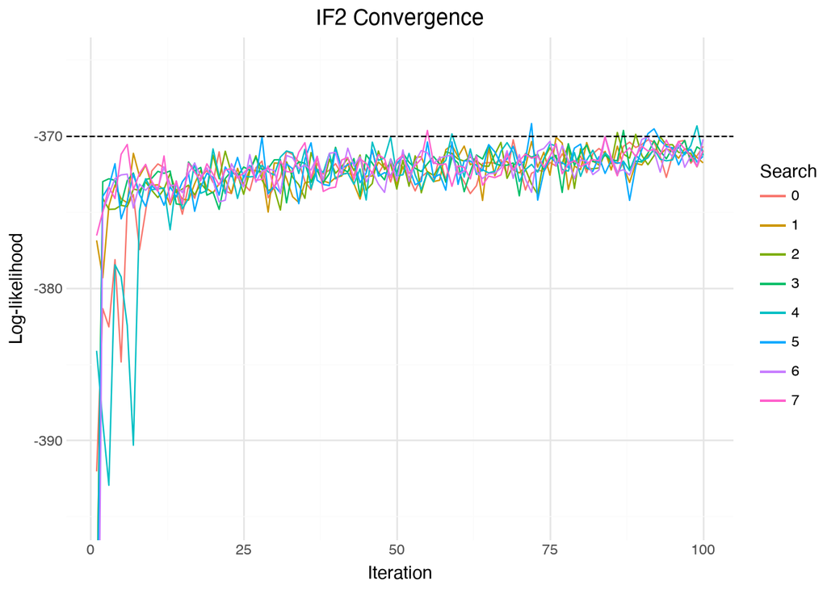

```python
(
    p9.ggplot(
        traces.query("method == 'mif' and iteration > 0"),
        p9.aes(x="iteration", y="logLik", color="factor(theta_idx)"),
    )
    + p9.geom_line()
    + p9.geom_hline(yintercept=mle_loglik, linetype="dashed")
    + p9.coord_cartesian(ylim=(mle_loglik - 25, mle_loglik + 5))
    + p9.theme_minimal()
    + p9.labs(x="Iteration", y="Log-likelihood", title="IF2 Convergence", color="Search")
)
```

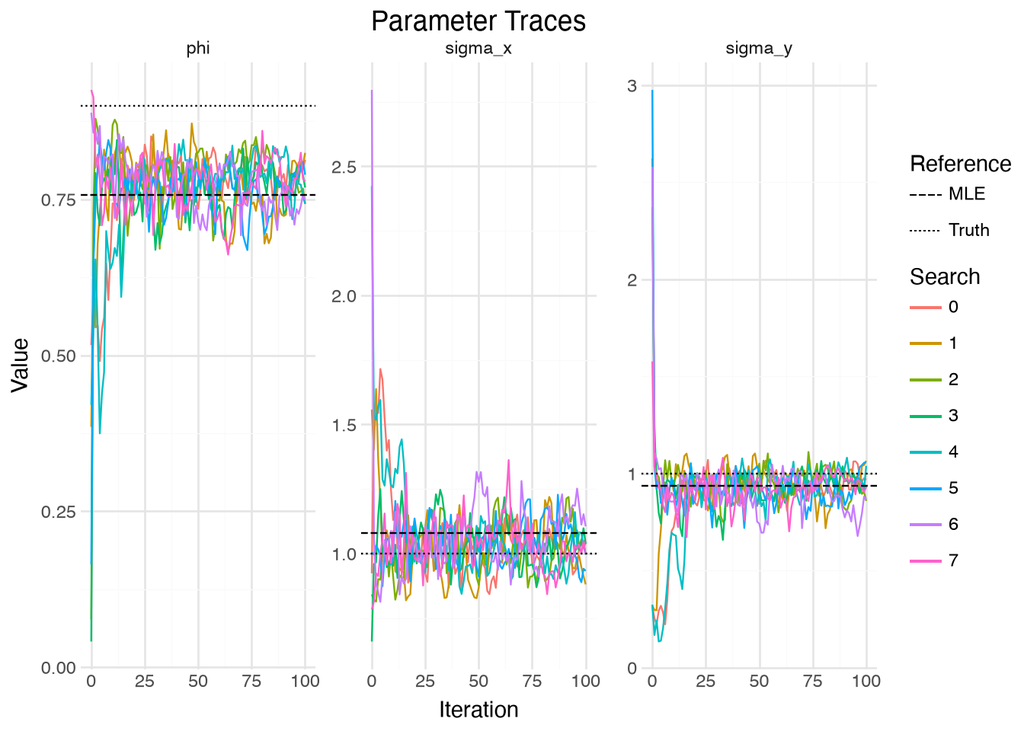

```python
param_names = list(theta_true)
traces_long = traces.query("method == 'mif'").melt(
    id_vars=["iteration", "theta_idx"], value_vars=param_names
)
reference = pd.DataFrame(
    {
        "variable": param_names,
        "Truth": [theta_true[k] for k in param_names],
        "MLE": [mle[k] for k in param_names],
    }
).melt(id_vars=["variable"], var_name="Reference", value_name="intercept")
(
    p9.ggplot(traces_long, p9.aes(x="iteration", y="value"))
    + p9.geom_line(p9.aes(color="factor(theta_idx)"))
    + p9.geom_hline(
        p9.aes(yintercept="intercept", linetype="Reference"),
        data=reference,
    )
    + p9.scale_linetype_manual(values={"Truth": "dotted", "MLE": "dashed"})
    + p9.facet_wrap("~variable", scales="free_y")
    + p9.theme_minimal()
    + p9.labs(
        x="Iteration",
        y="Value",
        title="Parameter Traces",
        color="Search",
        linetype="Reference",
    )
)
```

Finally, we compare the best IF2 estimate with the exact MLE and the true parameter values, evaluating the exact log-likelihood at each. The best IF2 estimate should be close to the exact MLE; any remaining gap reflects Monte Carlo error and the limited number of iterations. The gap between the MLE and the truth is statistical error, which would shrink with more data.

```python
best = ar1.results().sort_values("logLik", ascending=False).iloc[0]
best_if2 = {k: best[k] for k in param_names}
pd.DataFrame(
    [
        {**theta_true, "exact logLik": kalman_loglik(theta_true, y)},
        {**mle, "exact logLik": mle_loglik},
        {**best_if2, "exact logLik": kalman_loglik(best_if2, y)},
    ],
    index=["truth", "exact MLE", "best IF2 estimate"],
)
```

|  | phi | sigma_x | sigma_y | exact logLik |
| --- | --- | --- | --- | --- |
| truth | 0.900000 | 1.000000 | 1.000000 | -373.214523 |
| exact MLE | 0.756467 | 1.080946 | 0.937785 | -370.046225 |
| best IF2 estimate | 0.768908 | 1.037989 | 0.925975 | -370.187874 |

## Next Steps

- The Dhaka cholera tutorial builds a nonlinear model with covariates and fits it with a combination of IF2 and gradient-based optimization.
- The UK measles tutorial fits a panel model with 1,422 units.
- The SBIED short course covers simulation-based inference for POMP models in depth.